# Shade Influence on Hemileia vastatrix

Breanna Flores

2024-07-18

*Hemileia vastatrix is a fungus that has created significant losses to the coffee industry since the early 1900s.I was interested in studying the conditions that influence the spread of the disease in coffee plots. The study compares a monoculture and polyculture, exploring how shade coverage throughout the day influences how quickly the fungus infects the coffee plants.I hypothesize there will be a correlation between how much shade a coffee tree receives and the severity of infection on the species; I also predict the foliage age will be influenced by infection of the species.I used ANOVA for Test 1 to determine the statistical significance when comparing means for shade range and the amount of infected stems and Test 2 I ran a regression model (Poisson) to determine the significance between foliage age and infected stems. The ANOVA compared means between the amount of shade and infected stems observe, determining statistical significance; the poisson liner regression model determined that there was a significant relationship between the amount of infection and foliage age. These results signify that shade influences the spread of the disease and impacts foliage growth.*

*Hemileia vastatrix is a fungus that has created significant losses to the coffee industry since the early 1900s (Silva 2022). Coffea arabica is the coffee crop grown in Costa Rica and can take up to seven years to fully mature. When a tree becomes infected, the disease will take over the leaves and cause them to fall prematurely; this results in poor coffee beans, as the plant focuses all its energy towards fighting off the disease and creating healthy leaves (Arneson 2000). I was interested in studying the conditions that influence the spread of the disease in coffee plots. The study compares a monoculture and polyculture, exploring how shade coverage throughout the day influences how quickly the fungus infects the coffee plants. This data was collected at the beginning of wet season; coffee fruits are maturing, however the rain also causes favorable conditions for the disease to spread (Diggins 2023). I hypothesize there will be a correlation between how much shade a coffee tree receives and the severity of infection on the species; I also predict the foliage age will be influenced by infection of the species.*

*The data set analyzed two plots (L-5 and PL-13), each row is labeled with a letter and each tree has a corresponding number.Shade levels were categorized as full shade (2), partial shade (1), and no shade (0). For each tree, I recorded how many tree trunks were observed, the age of the leaves,the size of the tree, how many infected stems were observed, and how much shade the tree was receiving throughout the day. I hypothesize that the more shade a tree received, the more infected it would be. I also hypothesize that the infection will influence the age of foliage for the species. I began by creating a histogram to determine normality of the infected stems for my data, as it was a variable I am using in both tests. The histogram determine that the data is not normally distributed. I then created two box plots to depict any central tendencies and comparing the distribution of stems infected by shade range (test1) and stems infected by foliage age (test2). Knowing this I used ANOVA for Test 1 to determine the statistical significance when comparing means for shade range and the amount of infected stems and Test 2 I ran a regression model (Poisson) to determine the significance between foliage age and infected stems.*

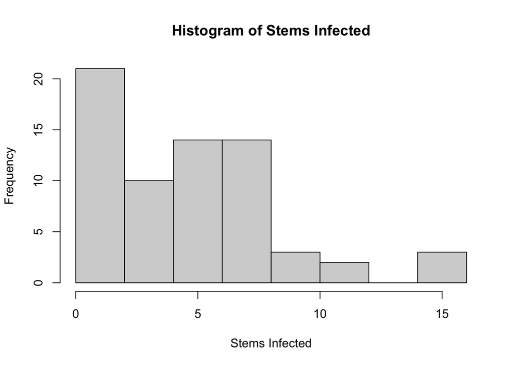

**TEST 1: Perform ANOVA to compare means for infected stems by shade range**

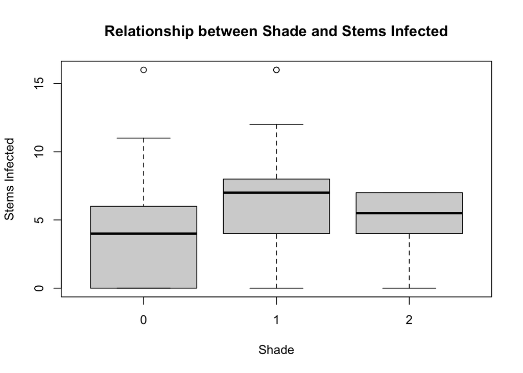

**TEST 2: Fit Poisson regression model to determine correlation between foliage and infected stems**

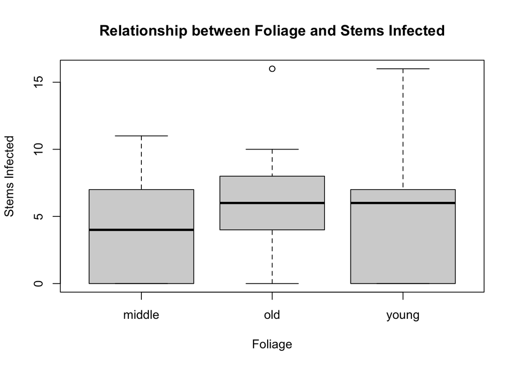

*As Test 1 determined, I expected to be statistically significance because, when comparing the means of stems infected and shade ranges, research determines that the germination occurs in moist conditions. Since the p-value is less than the significance and level, you reject the null hypothesis to conclude there is statistical significance to the variables. Test 2 determined there was statistical significance which I expected the old foliage to correlate to more infected stems because, according to research, the fungus germinates weaker species, and a younger plant would be likely stronger to fight off the disease. Since the p-value for old foliage is smaller than the significance level (0.05), we reject the null hypothesis that there is not a significant relationship. These results mean that their is an influence from shade, determining how the disease germinates and impacts foliage age. My analysis is limited because I chose two specific study sights that have different conditions, one is a monoculture and the other is a polyculture, as well as it only studies one species of coffee impacted by this fungus. The AIC for my regression model is also high, signifying the model is a weak fit to the data. There would be sources of bias as I collected this data during peak germination time for the disease. If I was given more time, I would analyze how spacing between species is influencing the germination process.*

**Work Cited**

*Arneson, P. A. (2000). Coffee rust. the Plant Health Instructor Index. https://doi.org/10.1094/phi-i-2000-0718-02*

*Diggins, K. (2023). La Roya confronting a coffee disease crisis in Costa Rica. Plant Health Instructor, 23(1). https://doi.org/10.1094/phi-c-2022-12-0007*

*Silva, M. D. C., Guerra-Guimarães, L., Diniz, I., Loureiro, A., Azinheira, H., Pereira, A. P., Tavares, S., Batista, D., & Várzea, V. (2022). An Overview of the Mechanisms Involved in Coffee-Hemileia vastatrix Interactions: Plant and Pathogen Perspectives. Agronomy, 12(2), 326. https://doi.org/10.3390/agronomy12020326*

*Wickham H, Averick M, Bryan J, Chang W, McGowan LD, François R, Grolemund G, Hayes A, Henry L, Hester J, Kuhn M, Pedersen TL, Miller E, Bache SM, Müller K, Ooms J, Robinson D, Seidel DP, Spinu V, Takahashi K, Vaughan D, Wilke C, Woo K, Yutani H (2019). “Welcome to the tidyverse.” *Journal of Open Source Software*,* 4*(43), 1686. doi:10.21105/joss.01686 https://doi.org/10.21105/joss.01686.*

*Wickham H, François R, Henry L, Müller K, Vaughan D (2023). *dplyr: A Grammar of Data Manipulation*. R package version 1.1.4, https://CRAN.R-project.org/package=dplyr.*

*Wickham H, Hester J, Bryan J (2024). *readr: Read Rectangular Text Data*.R package version 2.1.5, https://CRAN.R-project.org/package=readr.*

*Wickham H, ggplot2: Elegant Graphics for Data Analysis. Springer-Verlag New York, 2016.*

*William Revelle (2024). *psych: Procedures for Psychological, Psychometric, and Personality Research*. Northwestern University, Evanston, Illinois. R package version 2.4.6, https://CRAN.R-project.org/package=psych.*

**Appendix**

*# Subset data for each shade category and Check normality with Shapiro-Wilk test, run anova results*

```
##
##  Shapiro-Wilk normality test
##
## data:  shade_0
## W = 0.85648, p-value = 0.0002693
```

```
##
##  Shapiro-Wilk normality test
##
## data:  shade_1
## W = 0.93971, p-value = 0.1458
```

```
##
##  Shapiro-Wilk normality test
##
## data:  shade_2
## W = 0.84683, p-value = 0.1483
```

```
##               Df Sum Sq Mean Sq F value Pr(>F)
## factor(Shade)  2  111.0   55.49   3.568  0.034 *
## Residuals     64  995.3   15.55
## ---
## Signif. codes:  0 '***' 0.001 '**' 0.01 '*' 0.05 '.' 0.1 ' ' 1
```

*Summary of the poisson linear regression model*

```
##
## Call:
## glm(formula = Stems._Infected ~ Foliage, family = poisson, data = CLR_Data)
##
## Deviance Residuals:
##     Min       1Q   Median       3Q      Max
## -3.5518  -2.9221   0.0808   0.9288   4.0034
##
## Coefficients:
##              Estimate Std. Error z value Pr(>|z|)
## (Intercept)   1.45143    0.09492  15.292  < 2e-16 ***
## Foliageold    0.39034    0.14562   2.681  0.00735 **
## Foliageyoung  0.12164    0.12813   0.949  0.34244
## ---
## Signif. codes:  0 '***' 0.001 '**' 0.01 '*' 0.05 '.' 0.1 ' ' 1
##
## (Dispersion parameter for poisson family taken to be 1)
##
##     Null deviance: 277.18  on 66  degrees of freedom
## Residual deviance: 270.12  on 64  degrees of freedom
## AIC: 455.14
##
## Number of Fisher Scoring iterations: 5
```

*Citations for packages used*

```
##
##
##   Wickham H, Hester J, Bryan J (2024). _readr: Read Rectangular Text
##   Data_. R package version 2.1.5,
##   <https://CRAN.R-project.org/package=readr>.
##
## A BibTeX entry for LaTeX users is
##
##   @Manual{,
##     title = {readr: Read Rectangular Text Data},
##     author = {Hadley Wickham and Jim Hester and Jennifer Bryan},
##     year = {2024},
##     note = {R package version 2.1.5},
##     url = {https://CRAN.R-project.org/package=readr},
##   }
```

```
##
##
##   Wickham H, Averick M, Bryan J, Chang W, McGowan LD, François R,
##   Grolemund G, Hayes A, Henry L, Hester J, Kuhn M, Pedersen TL, Miller
##   E, Bache SM, Müller K, Ooms J, Robinson D, Seidel DP, Spinu V,
##   Takahashi K, Vaughan D, Wilke C, Woo K, Yutani H (2019). "Welcome to
##   the tidyverse." _Journal of Open Source Software_, *4*(43), 1686.
##   doi:10.21105/joss.01686 <https://doi.org/10.21105/joss.01686>.
##
## A BibTeX entry for LaTeX users is
##
##   @Article{,
##     title = {Welcome to the {tidyverse}},
##     author = {Hadley Wickham and Mara Averick and Jennifer Bryan and Winston Chang and Lucy D'Agostino McGowan and Romain François and Garrett Grolemund and Alex Hayes and Lionel Henry and Jim Hester and Max Kuhn and Thomas Lin Pedersen and Evan Miller and Stephan Milton Bache and Kirill Müller a…
##     year = {2019},
##     journal = {Journal of Open Source Software},
##     volume = {4},
##     number = {43},
##     pages = {1686},
##     doi = {10.21105/joss.01686},
##   }
```

```
##
##
##   H. Wickham. ggplot2: Elegant Graphics for Data Analysis.
##   Springer-Verlag New York, 2016.
##
## A BibTeX entry for LaTeX users is
##
##   @Book{,
##     author = {Hadley Wickham},
##     title = {ggplot2: Elegant Graphics for Data Analysis},
##     publisher = {Springer-Verlag New York},
##     year = {2016},
##     isbn = {978-3-319-24277-4},
##     url = {https://ggplot2.tidyverse.org},
##   }
```

```
##
##
##   William Revelle (2024). _psych: Procedures for Psychological,
##   Psychometric, and Personality Research_. Northwestern University,
##   Evanston, Illinois. R package version 2.4.6,
##   <https://CRAN.R-project.org/package=psych>.
##
## A BibTeX entry for LaTeX users is
##
##   @Manual{,
##     title = {psych: Procedures for Psychological, Psychometric, and Personality Research},
##     author = {{William Revelle}},
##     organization = {Northwestern University},
##     address = {Evanston, Illinois},
##     year = {2024},
##     note = {R package version 2.4.6},
##     url = {https://CRAN.R-project.org/package=psych},
##   }
```

```
##
##
##   Wickham H, François R, Henry L, Müller K, Vaughan D (2023). _dplyr: A
##   Grammar of Data Manipulation_. R package version 1.1.4,
##   <https://CRAN.R-project.org/package=dplyr>.
##
## A BibTeX entry for LaTeX users is
##
##   @Manual{,
##     title = {dplyr: A Grammar of Data Manipulation},
##     author = {Hadley Wickham and Romain François and Lionel Henry and Kirill Müller and Davis Vaughan},
##     year = {2023},
##     note = {R package version 1.1.4},
##     url = {https://CRAN.R-project.org/package=dplyr},
##   }
```